# Results_manuscript_draft

## Results

### Maturation Rate

Examine age to adult with no consideration of time to earlier instars

For analyses, I used the glmer function from Lme4 library to model the effects of sex, site, temp regime, and light regime on age of adulthood, assuming a normal distribution. I included the identity of the grasshopper’s mother as a random effect. I constructed 6 nested models: 1) including all interactions, 2) dropped 3- and 4-way interactions with sex, 3) only 2-way interactions, 4) all interactions not including sex, 5) sex removed completely, 6) sex and 3-way interaction removed completely. The preferred model (ΔAICc > 10) is the model including the main effects of all 4 varaiables, as well as all of their higher order interactions.

Plot based on individual means:

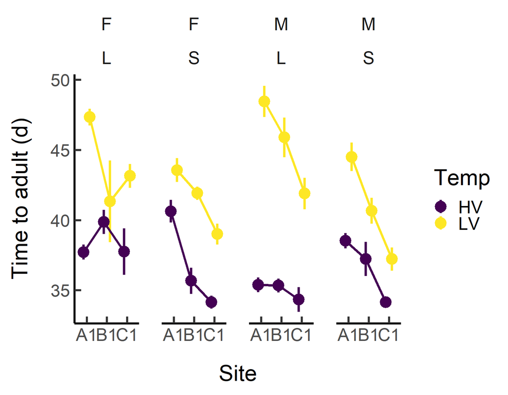

A plot of the LS-means and CI from this model are below (the equivalent of Rory’s fig1, but I made it appear like yours).

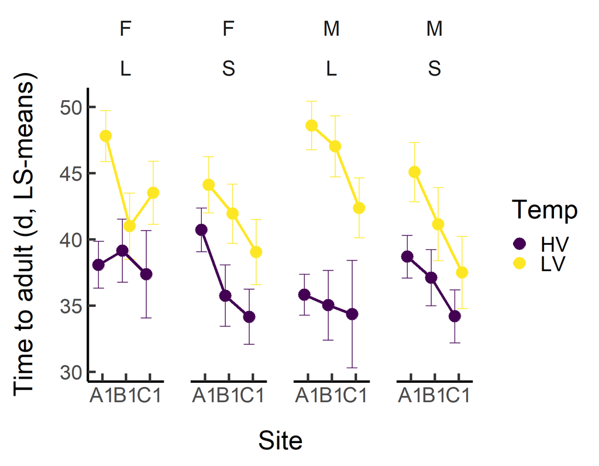

A plot of the LS-means and CI from this model are below (the direct equivalent of Rory’s fig1).

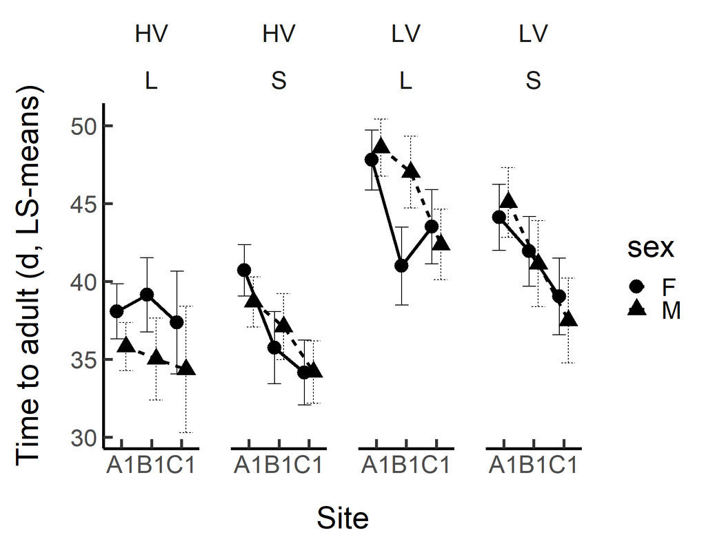

Here is an ANOVA table:

|  | Chisq | Df | Pr(>Chisq) | Signifcance |
| --- | --- | --- | --- | --- |
| (Intercept) | 1854.441 | 1 | 0.000 | *** |
| sex | 5.786 | 1 | 0.016 | * |
| Site | 0.874 | 2 | 0.646 |  |
| Temp | 54.884 | 1 | 0.000 | *** |
| Light | 4.836 | 1 | 0.028 | * |
| sex:Site | 1.188 | 2 | 0.552 |  |
| sex:Temp | 4.003 | 1 | 0.045 | * |
| Site:Temp | 13.697 | 2 | 0.001 | * |
| sex:Light | 0.033 | 1 | 0.856 |  |
| Site:Light | 11.949 | 2 | 0.003 | * |
| Temp:Light | 12.401 | 1 | 0.000 | *** |
| sex:Site:Temp | 9.006 | 2 | 0.011 | * |
| sex:Site:Light | 5.282 | 2 | 0.071 |  |
| sex:Temp:Light | 0.002 | 1 | 0.968 |  |
| Site:Temp:Light | 13.076 | 2 | 0.001 | * |
| sex:Site:Temp:Light | 12.012 | 2 | 0.002 | * |